# Potentially Hazardous Asteriods Prediction

Jay Gupta 19BPS1009, Aman Kumar Sinha 19BPS1026, Pritish Vilin Zunke 19BPS1119

# Analysis

```r
#libraries used
pacman::p_load(naivebayes)
pacman::p_load(e1071)
pacman::p_load(caret)
pacman::p_load(caTools)
pacman::p_load(tidyverse)
pacman::p_load(rpart)
pacman::p_load(Metrics)
pacman::p_load(adabag)
pacman::p_load(caTools)
pacman::p_load(dplyr)
pacman::p_load(neuralnet)
pacman::p_load(randomForest)
pacman::p_load(ggplot2)
options(warn = -1)
```

```r
data=read.csv("../dataset/dataset.csv")
```

```r
# Dimesion of dataset
dim(data)
```

```
## [1] 958524     45
```

```r
# Structure of dataset
str(data)
```

```
## 'data.frame':    958524 obs. of  45 variables:
##  $ id            : chr  "a0000001" "a0000002" "a0000003" "a0000004" ...
##  $ spkid         : int  2000001 2000002 2000003 2000004 2000005 2000006 2000007 2000008 2000009 2000010 ...
##  $ full_name     : chr  "     1 Ceres" "     2 Pallas" "     3 Juno" "     4 Vesta" ...
##  $ pdes          : chr  "1" "2" "3" "4" ...
##  $ name          : chr  "Ceres" "Pallas" "Juno" "Vesta" ...
##  $ prefix        : chr  "" "" "" "" ...
##  $ neo           : chr  "N" "N" "N" "N" ...
##  $ pha           : chr  "N" "N" "N" "N" ...
##  $ H             : num  3.4 4.2 5.33 3 6.9 5.8 5.6 6.5 6.3 5.5 ...
##  $ diameter      : num  939 545 247 525 107 ...
##  $ albedo        : num  0.09 0.101 0.214 0.423 0.274 ...
##  $ diameter_sigma: num  0.2 18 10.59 0.2 3.14 ...
##  $ orbit_id      : chr  "JPL 47" "JPL 37" "JPL 112" "JPL 35" ...
##  $ epoch         : num  2458601 2459001 2459001 2458601 2459001 ...
```

[output cut: 31 more lines]

H - An asteroid’s absolute magnitude is the visual magnitude an observer would record if the asteroid were placed 1 Astronomical Unit (au) away, and 1 au from the Sun and at a zero phase angle. The magnitude of an asteroid at zero phase angle and at unit heliocentric and geocentric distances.

Diameter - Diameter of asteroid

Albedo - is the measure of the diffuse reflection of solar radiation out of the total solar radiation and measured on a scale from 0, corresponding to a black body that absorbs all incident radiation, to 1, corresponding to a body that reflects all incident radiation Geometric albedo is the ratio of a body’s brightness at zero phase angle to the brightness of a perfectly diffusing disk with the same position and apparent size as the body. Our Moon has a very low albedo (0.07), while Venus has a high albedo (0.60). The albedo combined with the absolute magnitude can help determine the size of an asteroid.

Diameter_sigma - 1-sigma uncertainty in object diameter km Unit Epoch - In astronomy, an epoch or reference epoch is a moment in time used as a reference point for some time-varying astronomical quantity. It is useful for the celestial coordinates or orbital elements of a celestial body, as they are subject to perturbations and vary with time.

Eccentricity (e)- One half of the major axis of the elliptical orbit; also the mean distance from the Sun.

Inclination(i) - Orbital inclination measures the tilt of an object’s orbit around a celestial body. It is expressed as the angle between a reference plane and the orbital plane or axis of direction of the orbiting object.

moid - Minimum orbit intersection distance (MOID) is a measure used in astronomy to assess potential close approaches and collision risks between astronomical objects. It is defined as the distance between the closest points of the osculating orbits of two bodies

Note: all data fields starting with sigma are measurement uncertainty of corresponding feature.(standard deviation)

```r
# Removing prefix column as it has only NA values
data$prefix = NULL

data <- transform(
  data,
  neo = as.factor(neo),
  pha = as.factor(pha),
  orbit_id = as.factor(orbit_id),
  equinox = as.factor(equinox),
  class = as.factor(class)
)
# Removing rows with NAs
data <- na.omit(data)
data = droplevels(data)
```

```r
# Summary of dataset
summary(data)
```

```
##       id                spkid           full_name             pdes
##  Length:131142      Min.   : 2000001   Length:131142      Length:131142
##  Class :character   1st Qu.: 2047068   Class :character   Class :character
##  Mode  :character   Median : 2122334   Mode  :character   Mode  :character
##                     Mean   : 2212424
##                     3rd Qu.: 2247428
##                     Max.   :54000018
##
##      name           neo        pha              H            diameter
##  Length:131142      N:130403   N:130961   Min.   : 3.00   Min.   :  0.008
##  Class :character   Y:   739   Y:   181   1st Qu.:14.40   1st Qu.:  2.854
##  Mode  :character                         Median :15.20   Median :  4.059
##                                           Mean   :15.12   Mean   :  5.595
##                                           3rd Qu.:16.00   3rd Qu.:  5.862
##                                           Max.   :27.50   Max.   :939.400
##
##      albedo       diameter_sigma        orbit_id          epoch
##  Min.   :0.0010   Min.   :  0.0010   JPL 19 :  5139   Min.   :2452465
##  1st Qu.:0.0530   1st Qu.:  0.1770   JPL 20 :  5121   1st Qu.:2459001
##  Median :0.0790   Median :  0.3260   JPL 18 :  5120   Median :2459001
##  Mean   :0.1323   Mean   :  0.4778   JPL 17 :  5102   Mean   :2458994
##  3rd Qu.:0.1940   3rd Qu.:  0.6178   JPL 21 :  5048   3rd Qu.:2459001
##  Max.   :1.0000   Max.   :140.0000   JPL 22 :  4833   Max.   :2459001
##                                      (Other):100779
##    epoch_mjd       epoch_cal         equinox             e
##  Min.   :52464   Min.   :20020709   J2000:131142   Min.   :0.0003095
##  1st Qu.:59000   1st Qu.:20200531                  1st Qu.:0.0903302
##  Median :59000   Median :20200531                  Median :0.1393495
##  Mean   :58994   Mean   :20200361                  Mean   :0.1456958
##  3rd Qu.:59000   3rd Qu.:20200531                  3rd Qu.:0.1912756
##  Max.   :59000   Max.   :20200531                  Max.   :0.9837890
##
##        a                  q                  i                   om
##  Min.   :  0.6262   Min.   : 0.08182   Min.   :  0.02206   Min.   :  0.0004
##  1st Qu.:  2.5515   1st Qu.: 2.07847   1st Qu.:  4.97798   1st Qu.: 82.0982
##  Median :  2.7606   Median : 2.37703   Median :  9.13462   Median :160.2020
##  Mean   :  2.8282   Mean   : 2.41384   Mean   : 10.06813   Mean   :169.4861
##  3rd Qu.:  3.0976   3rd Qu.: 2.69415   3rd Qu.: 13.41217   3rd Qu.:255.0890
##  Max.   :376.1333   Max.   :40.31848   Max.   :170.33459   Max.   :359.9998
##
```

[output cut: 33 more lines]

```
##  Min.   :    0.00   Min.   :  0.00000   Min.   : 0.00000   Min.   :     0.00
##  1st Qu.:    0.00   1st Qu.:  0.00000   1st Qu.: 0.00000   1st Qu.:     0.00
##  Median :    0.00   Median :  0.00000   Median : 0.00000   Median :     0.00
##  Mean   :    1.07   Mean   :  0.01279   Mean   : 0.00132   Mean   :     4.03
##  3rd Qu.:    0.00   3rd Qu.:  0.00000   3rd Qu.: 0.00000   3rd Qu.:     0.00
##  Max.   :34512.00   Max.   :218.87000   Max.   :32.74700   Max.   :116450.00
##
##    sigma_per             class             rms
##  Min.   :     0.00   MBA    :120392   Min.   :0.07837
##  1st Qu.:     0.00   OMB    :  7298   1st Qu.:0.51026
##  Median :     0.00   TJN    :  1872   Median :0.54435
##  Mean   :     9.92   IMB    :   451   Mean   :0.54390
##  3rd Qu.:     0.00   APO    :   429   3rd Qu.:0.57844
##  Max.   :150130.00   MCA    :   324   Max.   :7.72510
##                      (Other):   376
```

### Correlation Matrix

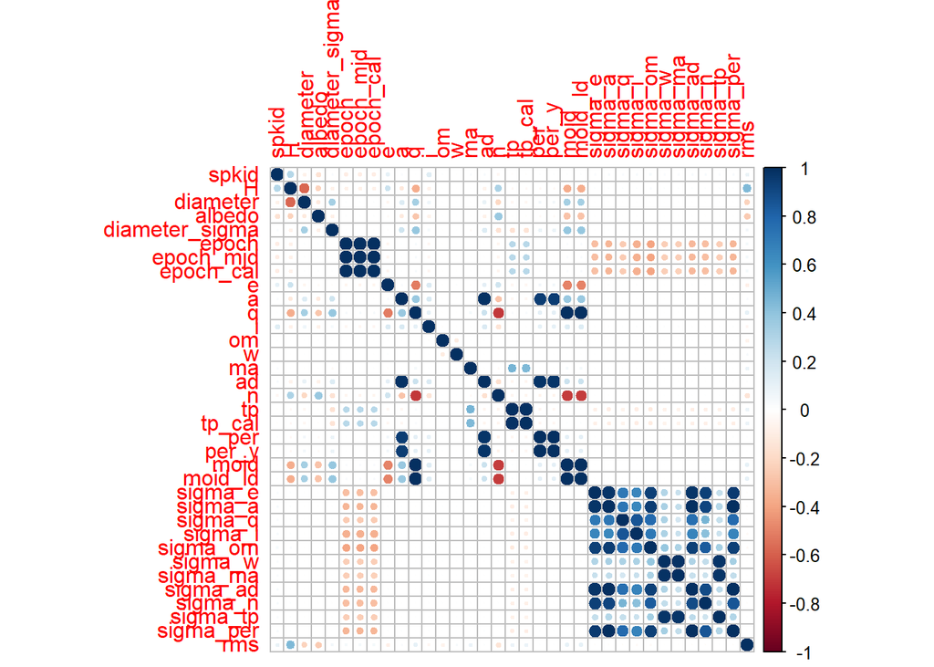

```r
correlationMatrix <- cor(Filter(is.numeric, data))
corrplot::corrplot(correlationMatrix)
```

### Plot asteroids diameter distribution

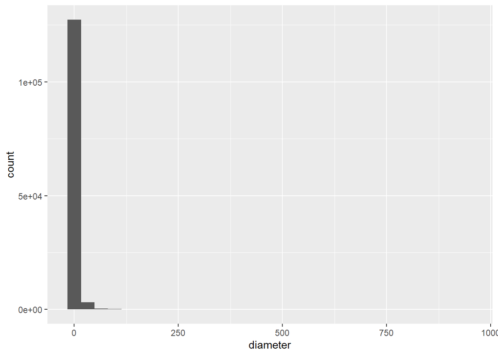

```r
ggplot(data, aes(x = diameter)) + geom_histogram()
```

### Plot asteroids diameter distribution(with x limit)

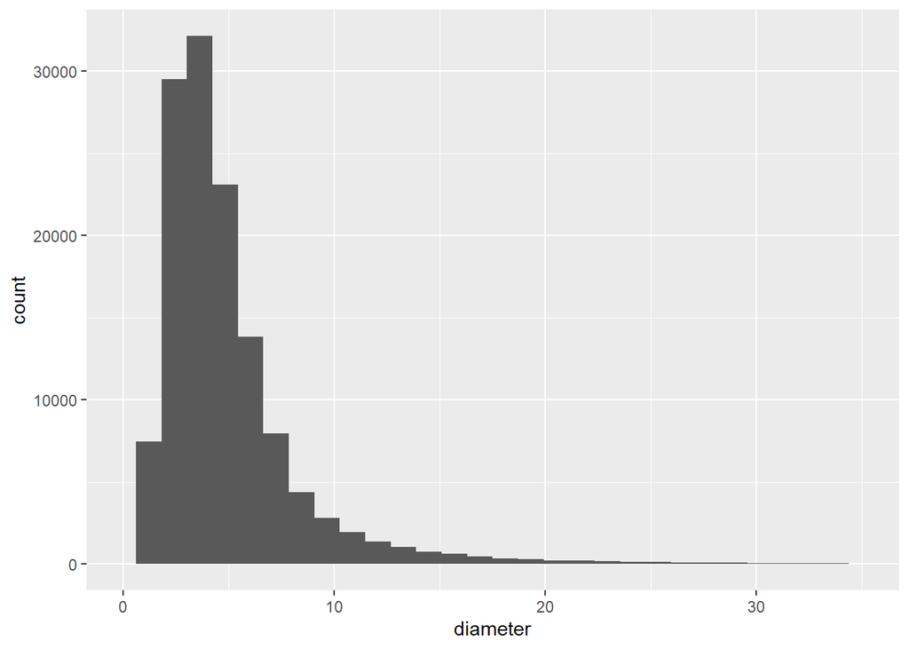

```r
# Plot asteroids diameter distribution
ggplot(data, aes(x = diameter)) + geom_histogram()+xlim(0,35)
```

Most of the asteroids have a diameter of range 0-10 km.

### Plot asteroids diameter distribution (for PHA)

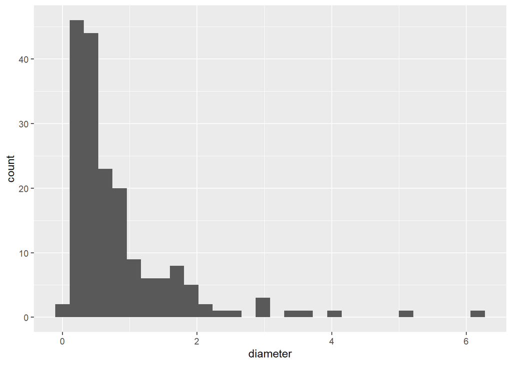

```r
# Plot asteroids diameter distribution
data%>%
  filter(pha=='Y')%>%
  ggplot(aes(x = diameter)) + geom_histogram()
```

Most of the Potentially Hazardous Asteroids have a diameter of 0-2.5 km.

### Plot potentially hazardous asteroids distribution

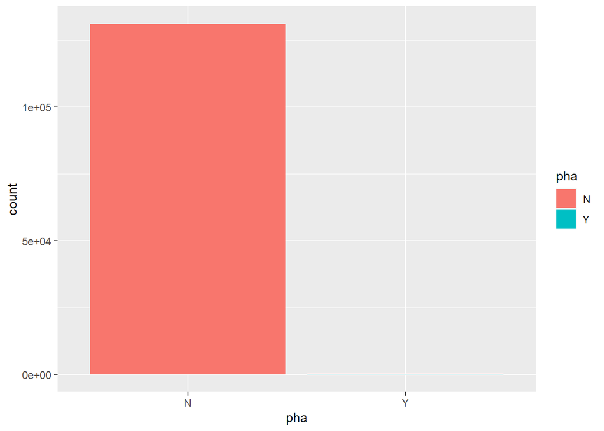

```r
ggplot(data, aes(x = pha, fill = pha)) + geom_bar()
```

### Plot near earth object distribution

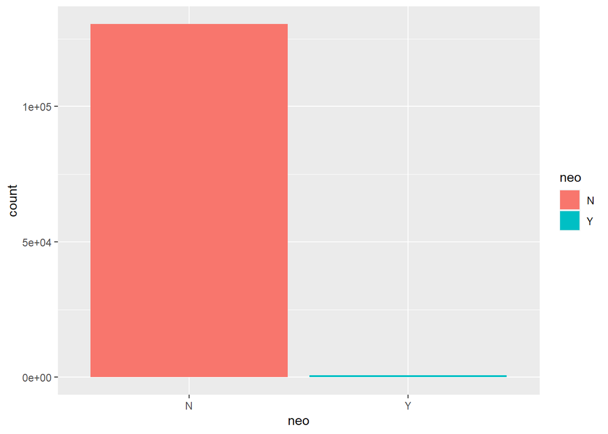

```r
ggplot(data, aes(x = neo, fill = neo)) + geom_bar()
```

### Plot potentially hazardous asteroids distribution

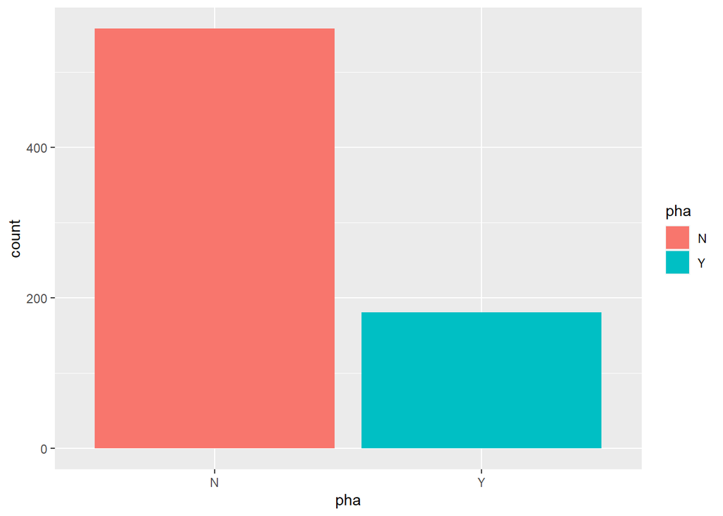

```r
data%>%
  filter(neo=='Y')%>%
  ggplot(aes(x = pha, fill = pha)) + geom_bar()
```

NEOs that are PHAs.

### Scatter plot between Earth Minimum Orbit Intersection Distance and diameter

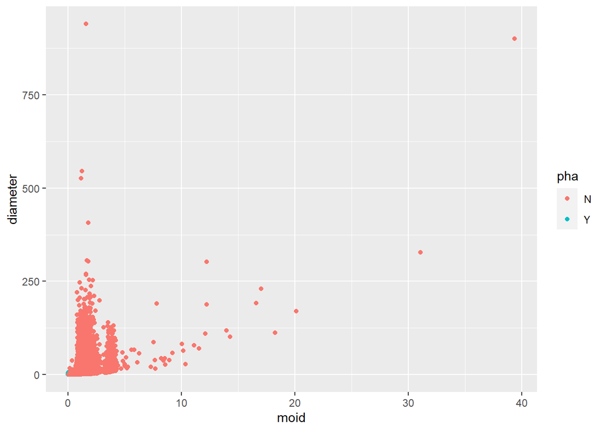

```r
ggplot(data, aes(x = moid, y=diameter)) + geom_point(aes(colour=pha))
```

### Scatter plot between Earth Minimum Orbit Intersection Distance and diameter(with x and y limits)

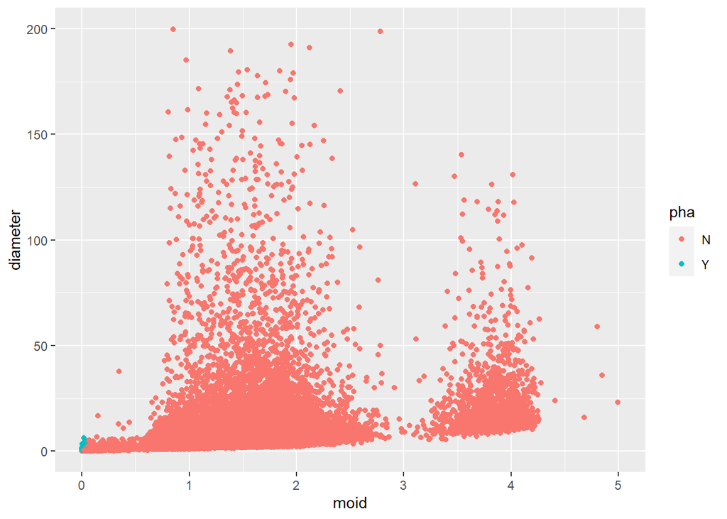

```r
ggplot(data, aes(x = moid, y=diameter)) + geom_point(aes(colour=pha))+xlim(0,5)+ylim(0,200)
```

### Scatter plot between Earth Minimum Orbit Intersection Distance and diameter (for PHA)

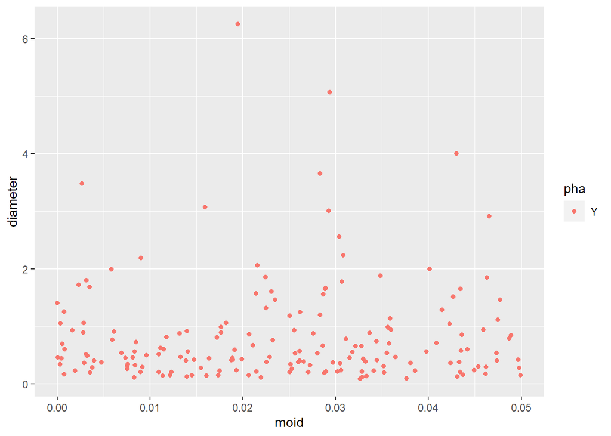

```r
data%>%
  filter(pha=='Y')%>%
  ggplot(aes(x = moid, y=diameter)) + geom_point(aes(colour=pha))
```

Most of the PHA have diameter less than 2 km and Earth Minimum Orbit Intersection Distance less than 0.05.

### Scatter plot between Earth Minimum Orbit Intersection Distance and absolute magnitude parameter

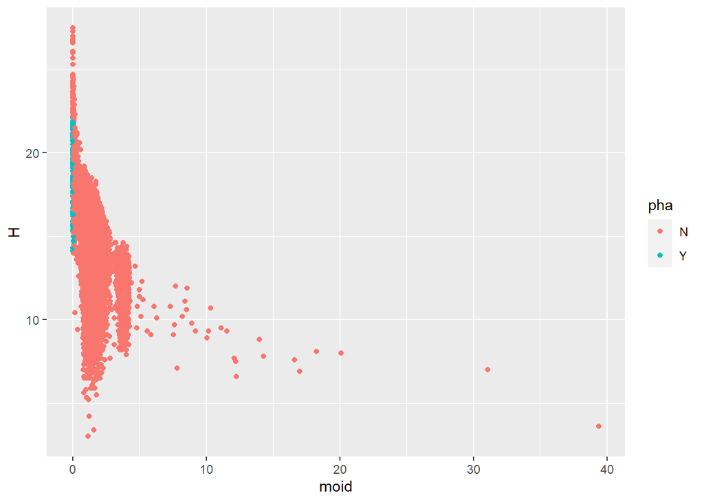

```r
ggplot(data, aes(x = moid, y=H)) + geom_point(aes(colour=pha))
```

### Scatter plot between Earth Minimum Orbit Intersection Distance and absolute magnitude parameter(with x limit)

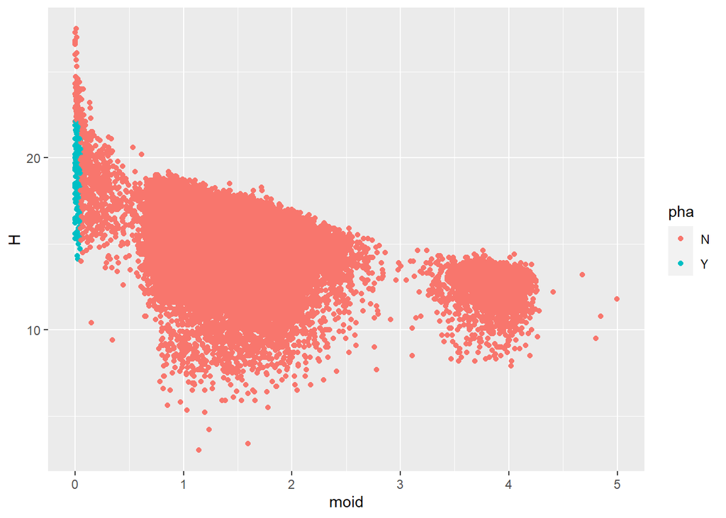

```r
ggplot(data, aes(x = moid, y=H)) + geom_point(aes(colour=pha))+xlim(0,5)
```

### Scatter plot between Earth Minimum Orbit Intersection Distance and absolute magnitude parameter (for PHA)

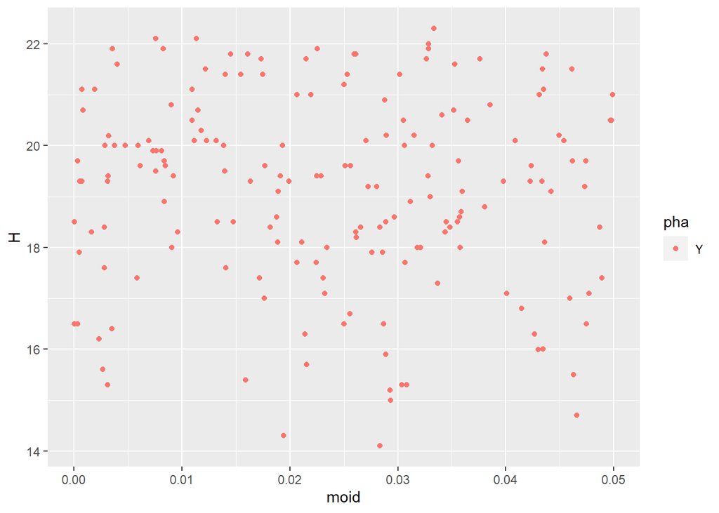

```r
data%>%
  filter(pha=='Y')%>%
  ggplot(aes(x = moid, y=H)) + geom_point(aes(colour=pha))
```

### Scatter plot between diameter and absolute magnitude parameter

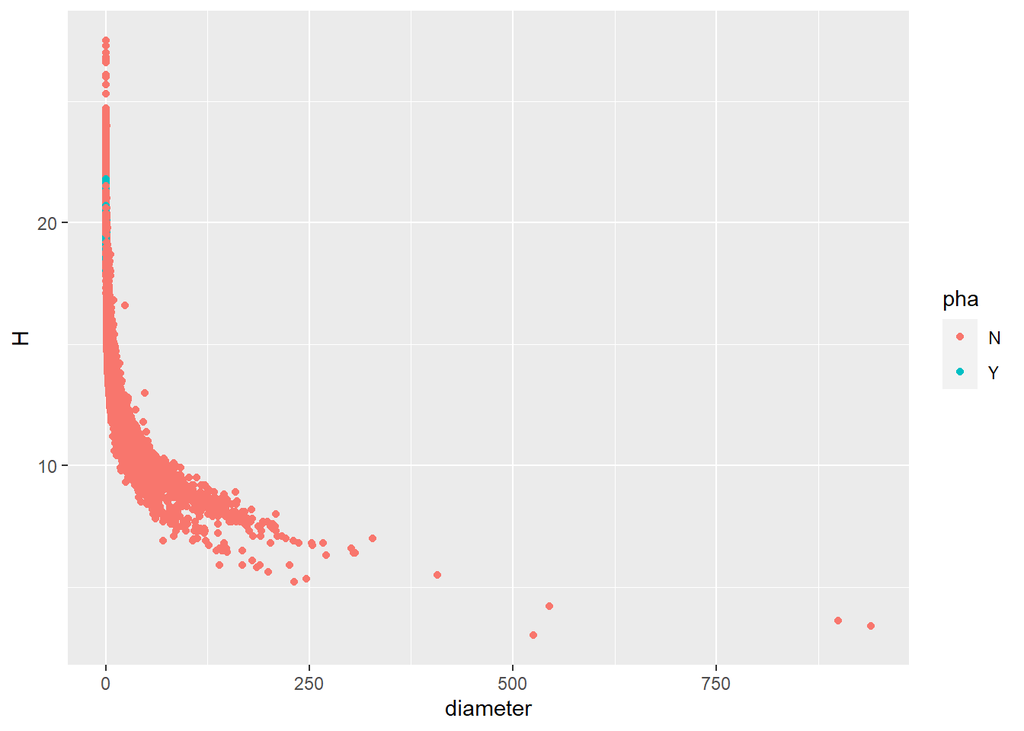

```r
ggplot(data, aes(x = diameter, y=H)) + geom_point(aes(colour=pha))
```

### Scatter plot between diameter and absolute magnitude parameter(with x limit)

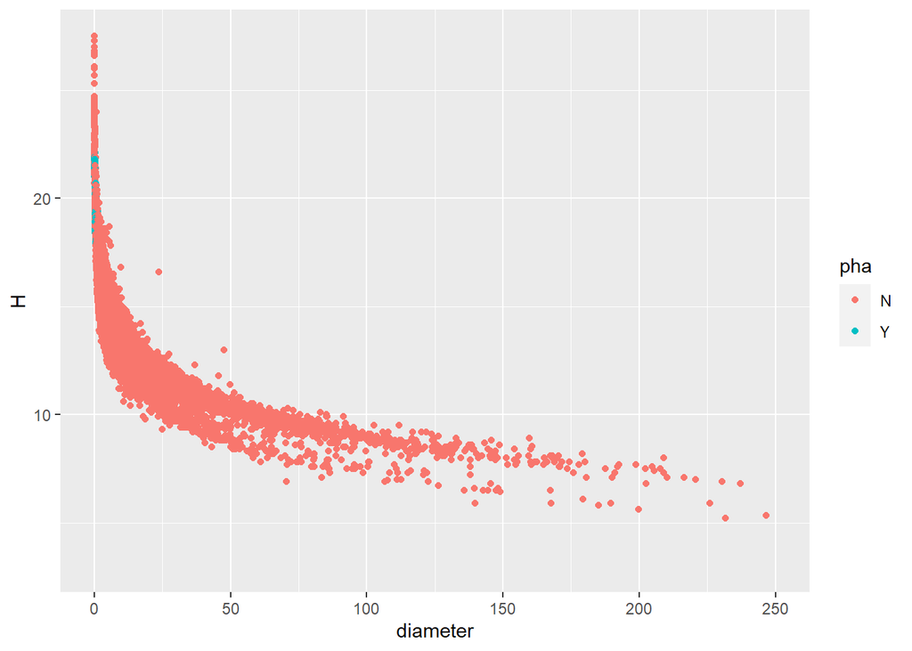

```r
ggplot(data, aes(x = diameter, y=H)) + geom_point(aes(colour=pha))+xlim(0,250)
```

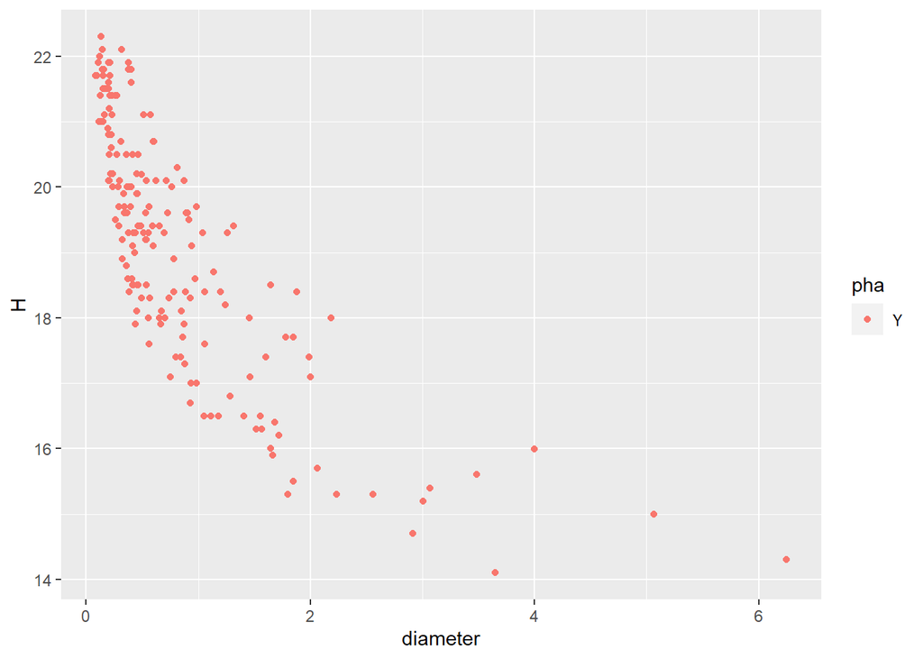

```r
data%>%
  filter(pha=='Y')%>%
  ggplot(aes(x = diameter, y=H)) + geom_point(aes(colour=pha))
```

PHA with lesser diameter have higher absolute magnitude parameter.

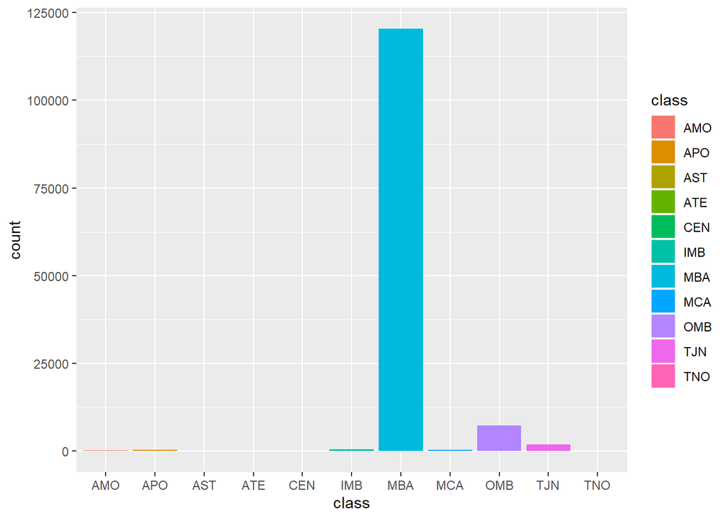

```r
ggplot(data, aes(x = class, fill = class)) + geom_bar()
```

# Predictions

```r
# Load dataset
df <- read.csv("../dataset/balanced_dataset.csv")
```

```r
#data cleaning and feature selection
featureSelection <- function(data) {
  # Highly correlated features
  correlationMatrix <- cor(data[, names(data) != "pha"])

  # Index of highly correlation features
  hightlyCorrelated <- findCorrelation(correlationMatrix,
                                       cutoff = 0.95, names = TRUE)

  # Remove highly correlated features
  data <- data[, !names(data) %in% hightlyCorrelated]
  return(data)
}


dataCleaning <- function(data) {
  # Remove unnecessary field
  data <- data[, !names(data)
               %in% c("prefix", "id", "spkid", "full_name", "pdes",
                      "name", "orbit_id", "equinox", "neo", "class","X")]

  # Remove NA data
  data <- na.omit(data)

  # Categorical data
  data <- transform(
    data,
    pha = as.factor(pha)
  )

  return(data)
}
```

## Cleaning data and Feature selection

```r
df <- dataCleaning(df)

df <- featureSelection(df)
```

## Naive Bayes

```r
options(warn = -1)
# Split dataset
sample = sample.split(df$pha, SplitRatio = 0.75)
train = subset(df, sample == TRUE)
test = subset(df, sample == FALSE)

# Create model
model <- naive_bayes(pha ~ ., data = train)
model
```

```
##
## ================================== Naive Bayes ==================================
##
##  Call:
## naive_bayes.formula(formula = pha ~ ., data = train)
##
## ---------------------------------------------------------------------------------
##
## Laplace smoothing: 0
##
## ---------------------------------------------------------------------------------
##
##  A priori probabilities:
##
##   N   Y
## 0.5 0.5
##
## ---------------------------------------------------------------------------------
##
##  Tables:
##
## ---------------------------------------------------------------------------------
##  ::: H (Gaussian)
## ---------------------------------------------------------------------------------
##
## H              N         Y
##   mean 15.085879 20.078366
##   sd    1.359935  1.442121
##
## ---------------------------------------------------------------------------------
##  ::: diameter (Gaussian)
## ---------------------------------------------------------------------------------
##
## diameter          N          Y
##     mean  6.2652252  0.5463748
##     sd   25.0017353  0.5233444
##
## ---------------------------------------------------------------------------------
##  ::: albedo (Gaussian)
## ---------------------------------------------------------------------------------
```

[output cut: 11 more lines]

```
##           sd   0.52906105 0.15355103
##
## ---------------------------------------------------------------------------------
##  ::: epoch_cal (Gaussian)
## ---------------------------------------------------------------------------------
##
## epoch_cal            N            Y
##      mean 20200395.243 20192758.972
##      sd       3605.589    33100.887
##
## ---------------------------------------------------------------------------------
##
## # ... and 15 more tables
##
## ---------------------------------------------------------------------------------
```

```r
# Predict test set
pred <- predict(model, test)
confusionMatrix(table(test$pha, pred))
```

```
## Confusion Matrix and Statistics
##
##    pred
##       N   Y
##   N 514   2
##   Y   4 512
##
##                Accuracy : 0.9942
##                  95% CI : (0.9874, 0.9979)
##     No Information Rate : 0.5019
##     P-Value [Acc > NIR] : <2e-16
##
##                   Kappa : 0.9884
##
##  Mcnemar's Test P-Value : 0.6831
##
##             Sensitivity : 0.9923
##             Specificity : 0.9961
##          Pos Pred Value : 0.9961
##          Neg Pred Value : 0.9922
##              Prevalence : 0.5019
##          Detection Rate : 0.4981
##    Detection Prevalence : 0.5000
##       Balanced Accuracy : 0.9942
##
##        'Positive' Class : N
##
```

## Decision Tree

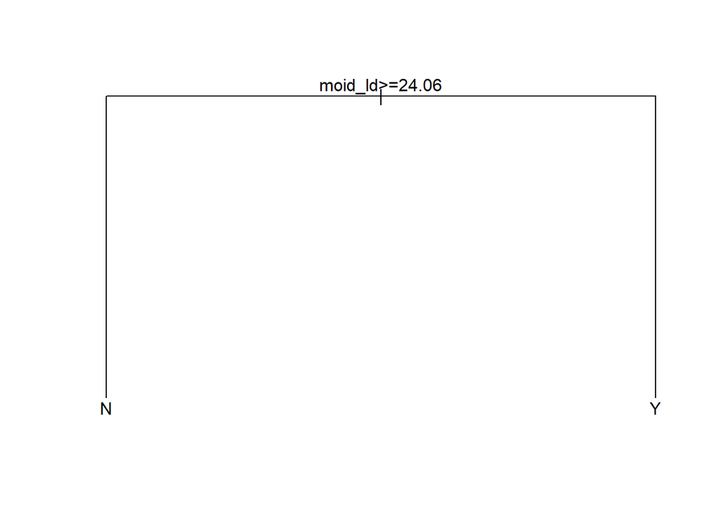

```r
training.samples <- df$pha %>%
  createDataPartition(p = 0.8, list = FALSE)
train.data  <- df[training.samples, ]
test.data <- df[-training.samples, ]
model <- rpart(pha ~., data = train.data, method = "class")
# Plot the trees
par(xpd = NA) # Avoid clipping the text in some device
plot(model)
text(model, digits = 3)
```

```r
# Make predictions on the test data
predicted.classes <- model %>%
  predict(test.data, type = "class")
# Compute model accuracy rate on test data
accuracy=mean(predicted.classes == test.data$pha)
cat("Accuracy:",accuracy,"\n")
```

```
## Accuracy: 0.9987893
```

```r
confusionMatrix(test.data$pha,predicted.classes)
```

```
## Confusion Matrix and Statistics
##
##           Reference
## Prediction   N   Y
##          N 412   1
##          Y   0 413
##
##                Accuracy : 0.9988
##                  95% CI : (0.9933, 1)
##     No Information Rate : 0.5012
##     P-Value [Acc > NIR] : <2e-16
##
##                   Kappa : 0.9976
##
##  Mcnemar's Test P-Value : 1
##
##             Sensitivity : 1.0000
##             Specificity : 0.9976
##          Pos Pred Value : 0.9976
##          Neg Pred Value : 1.0000
##              Prevalence : 0.4988
##          Detection Rate : 0.4988
##    Detection Prevalence : 0.5000
##       Balanced Accuracy : 0.9988
##
##        'Positive' Class : N
##
```

## Random Forest

```r
sample = sample.split(df$pha, SplitRatio = 0.75)
train = subset(df, sample == TRUE)
test = subset(df, sample == FALSE)
# Create model
model <- randomForest(pha ~ ., data = train)
model
```

```
##
## Call:
##  randomForest(formula = pha ~ ., data = train)
##                Type of random forest: classification
##                      Number of trees: 500
## No. of variables tried at each split: 4
##
##         OOB estimate of  error rate: 0.13%
## Confusion matrix:
##      N    Y class.error
## N 1546    4 0.002580645
## Y    0 1550 0.000000000
```

```r
# Predict test set
pred = predict(model, test)
confusionMatrix(table(test$pha, pred))
```

```
## Confusion Matrix and Statistics
##
##    pred
##       N   Y
##   N 516   0
##   Y   0 516
##
##                Accuracy : 1
##                  95% CI : (0.9964, 1)
##     No Information Rate : 0.5
##     P-Value [Acc > NIR] : < 2.2e-16
##
##                   Kappa : 1
##
##  Mcnemar's Test P-Value : NA
##
##             Sensitivity : 1.0
##             Specificity : 1.0
##          Pos Pred Value : 1.0
##          Neg Pred Value : 1.0
##              Prevalence : 0.5
##          Detection Rate : 0.5
##    Detection Prevalence : 0.5
##       Balanced Accuracy : 1.0
##
##        'Positive' Class : N
##
```

## Neural Network

```r
df$pha <- ifelse(df$pha=='N',0,1)
# Split dataset
sample = sample.split(df$pha, SplitRatio = 0.75)
train = subset(df, sample == TRUE)
test = subset(df, sample == FALSE)
#create model
model <- neuralnet::neuralnet(formula=pha ~ ., data = train, hidden=2,act.fct = "tanh",err.fct = "sse")
# Predict test set
pred <- neuralnet::compute(model,subset(test,select=-c(pha)))
pred$net.result <- ifelse(pred$net.result>0.5, 1, 0)
u <- union(pred$net.result, test$pha)
t <- table(factor(test$pha, u),factor(pred$net.result, u))
confusionMatrix(t)
```

```
## Confusion Matrix and Statistics
##
##
##       0   1
##   0 516   0
##   1 516   0
##
##                Accuracy : 0.5
##                  95% CI : (0.469, 0.531)
##     No Information Rate : 1
##     P-Value [Acc > NIR] : 1
##
##                   Kappa : 0
##
##  Mcnemar's Test P-Value : <2e-16
##
##             Sensitivity : 0.5
##             Specificity :  NA
##          Pos Pred Value :  NA
##          Neg Pred Value :  NA
##              Prevalence : 1.0
##          Detection Rate : 0.5
##    Detection Prevalence : 0.5
##       Balanced Accuracy :  NA
##
##        'Positive' Class : 0
##
```

## Logistic Regression

```r
options(warn = -1)
df$pha <- factor(df$pha)

# Split dataset
sample = sample.split(df$pha, SplitRatio = 0.75)
train = subset(df, sample == TRUE)
test = subset(df, sample == FALSE)

#create model
model <- glm(formula=pha ~ ., data = train, family = "binomial")
model
```

```
##
## Call:  glm(formula = pha ~ ., family = "binomial", data = train)
##
## Coefficients:
##    (Intercept)               H        diameter          albedo  diameter_sigma
##      1.111e+16       3.043e+14       3.462e+12       6.454e+14      -1.622e+14
##      epoch_cal               e               i              om               w
##     -6.480e+09       6.488e+15       7.078e+12      -2.211e+11       4.021e+11
##             ma              ad               n          tp_cal             per
##     -1.042e+11      -2.087e+15      -1.396e+15       5.798e+09       3.011e+12
##        moid_ld         sigma_i        sigma_om        sigma_ad        sigma_tp
##     -2.937e+12      -8.608e+12       3.355e+13       4.872e+13      -5.322e+12
##            rms
##     -2.379e+15
##
## Degrees of Freedom: 3099 Total (i.e. Null);  3079 Residual
## Null Deviance:       4298
## Residual Deviance: 504.6     AIC: 546.6
```

```r
# Predict test set
pred <- predict(model, test, type="response")
pred <- ifelse(pred >0.5, 1, 0)
confusionMatrix(table(test$pha, pred))
```

```
## Confusion Matrix and Statistics
##
##    pred
##       0   1
##   0 516   0
##   1   2 514
##
##                Accuracy : 0.9981
##                  95% CI : (0.993, 0.9998)
##     No Information Rate : 0.5019
##     P-Value [Acc > NIR] : <2e-16
##
##                   Kappa : 0.9961
##
##  Mcnemar's Test P-Value : 0.4795
##
##             Sensitivity : 0.9961
##             Specificity : 1.0000
##          Pos Pred Value : 1.0000
##          Neg Pred Value : 0.9961
##              Prevalence : 0.5019
##          Detection Rate : 0.5000
##    Detection Prevalence : 0.5000
##       Balanced Accuracy : 0.9981
##
##        'Positive' Class : 0
##
```

We have balanced the dataset using undersampling, accuracy for logistic regression has increased. Ensemble models and decision tree that is the tree based models have the highest accuracy and the best performance amongst all. Using these models we were successfully able to classify near earth objects into potentially hazardous and non hazardous asteroids.